# Classification of Parkinson’s disease using Vocal Shimmer, Jitter, and Speech Measurements

## Introduction

Parkinson’s Disease is a neurological disorder effecting more than 6 million people worldwide that impacts individuals motor skills, speech and cognitive abilities.[1] There are currently no tests that are able to use biomarkers to accurately identify and diagnose Parkinson’s Disease (PD). Therefore, diagnosis of PD is reliant on clinical observation of the symptoms of PD. Relying on the presence of these symptoms prevents early diagnosis, and costs the effected individuals valuable time in getting treatment to slow the progression of the disease. One option to improve the early diagnosis of PD is to use speech data, which had been found to be one of the earliest detectable PD symptoms.[1] Using the biomedical voice measurements data from [2], we will attempt to use various data analytics methods to classify potential PD cases.

## Objectives

- Identify which explanatory variables to use in classifying Parkinson’s disease status
- Build a Logistic Regression and a Random Forest Classification model to classify Parkinson’s disease status
- Compare the models to find which is best at classifying Parkinson’s disease status

## Analysis Plan

### Exploratory Data Analysis

Exploring this dataset was accomplished mainly through thorough research of the various features to see what they mean and how they can be used. This gave us a lot of insight into the data as at first we were unsure where to begin with feature selection. We also did basic statistics on the fields to ensure that there weren’t outliers and that the data was clean and complete.

### Data Analytics Methods

After using the feature selection we then split the data into a training and a testing set of data. We did 70% for training and the remaining 30% were used for testing. This meant we ended up with 136 records for training and 59 records for testing.

The machine learning models we considered for this analysis were **Logistic Regression**, **Decision Tree**, **Random Forest**, and **Support Vector Machines**. These models are first trained on the training data and then tested against the testing data after the model has been trained. The results that the model gives are then compared to the expected results (whether someone has Parkinson’s disease) and rate of miss-classification and confusion matrix are then created. The **rate of miss-classification** is created by subtracting the mean of the amount of correct observations from 1. This gives us a percentage of the time the model make an incorrect prediction. To create the **confusion matrix** we use the **kable()** method to create a table of the amount of observations that have Parkinson’s and those that do not for both the testing dataset and the predictions the model gives us.

### Data Summary

The features from the dataset we will be looking at include: MDVP.Fhi(Hz), MDVP:Flo(Hz), NHR, RPDE, DFA, spread2 and status.

**MDVP.Fhi(Hz)** is the maximum vocal fundamental frequency in Hertz and **MDVP:Flo(Hz)** is the minimum vocal fundamental frequency in Hertz. This is calculated using the **Kay Pentax Multidimensional Voice Program (MDVP)**. The fundamental frequency is the lowest frequency of vibration in a sound wave and is what determines the pitch of the sound. [5]

```r
summary(parkinsons_data$MDVP.Fhi.Hz.)
```

```
##    Min. 1st Qu.  Median    Mean 3rd Qu.    Max.
##   102.1   134.9   175.8   197.1   224.2   592.0
```

**NHR** stands for Noise-to-Harmonic Ratio, and it is calculated by dividing the energy of the tonal components in the voice by the energy of the noise components. It is a useful measure for assessing vocal health and can be used to identify changes in vocal quality that may be associated with conditions such as vocal cord nodules, vocal cord paralysis, and Parkinson’s disease. [4]

```r
summary(parkinsons_data$NHR)
```

```
##     Min.  1st Qu.   Median     Mean  3rd Qu.     Max.
## 0.000650 0.005925 0.011660 0.024847 0.025640 0.314820
```

**RPDE** stands for Rescaled Phase Dependent Entropy. It is a measure of the complexity of a time series that is based on the distribution of the phases of the constituent frequencies. It is a useful measures for assessing the complexity of a time series. They can be used to identify changes in the complexity of a time series that may be associated with changes in the underlying system. For example, RPDE has been used to study the changes in the complexity of the voice that are associated with Parkinson’s disease. [3]

```r
summary(parkinsons_data$RPDE)
```

```
##    Min. 1st Qu.  Median    Mean 3rd Qu.    Max.
##  0.2566  0.4213  0.4960  0.4985  0.5876  0.6852
```

**DFA** stands forDetrended fluctuation analysis (DFA) is a measure of the similarity of noise in speech signals. It is used to identify voice disorders by measuring the scaling exponent of the noise. A higher scaling exponent indicates a more disordered signal, which is associated with voice disorders. [3]

```r
summary(parkinsons_data$DFA)
```

```
##    Min. 1st Qu.  Median    Mean 3rd Qu.    Max.
##  0.5743  0.6748  0.7223  0.7181  0.7619  0.8253
```

**spread2** is a measure of the unevenness of the distribution of fundamental frequencies in a voice signal. It is calculated as the standard deviation of the fundamental frequencies in the signal. A higher spread2 value indicates a more variable fundamental frequency, which is associated with voice disorders. [6]

```r
summary(parkinsons_data$spread2)
```

```
##     Min.  1st Qu.   Median     Mean  3rd Qu.     Max.
## 0.006274 0.174350 0.218885 0.226510 0.279234 0.450493
```

**status** is a binary attribute that states whether the person has Parkinson’s (1) or does not have Parkinson’s (0).

```r
summary(parkinsons_data$status)
```

```
##    Min. 1st Qu.  Median    Mean 3rd Qu.    Max.
##  0.0000  1.0000  1.0000  0.7538  1.0000  1.0000
```

## Data Analysis and Results

### Feature Selection

To select the features to be used in the models, we first examined the correlation matrix from all 22 features(Figure 1). Since the features all came from biomedical voice measurements, some of the features were likely to be heavily correlated, and thus redundant. Looking at the correlation heat map in figure 1, there are a large number of the features that are significantly correlated. Using the findCorrelation() function we identified the features with an absolute correlation over 0.5, and excluded them from our feature list. This left us with the 6 features that we used for our models. Getting rid of these redundant features improves the models accuracy, and reduces over-fitting.

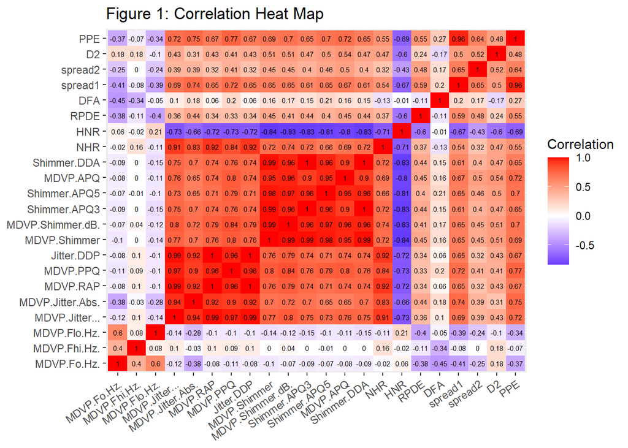

### Machine Learning Algorithms

We used Logistic Regression, Decision Tree, Random Forest (RF), and Support Vector Machines (SVM) models to classify our data as having PD or not. The logistic regression model assigns a value of the predicted probability of having PD for each observation in the testing data set. We then assigned all the cases with probability > 0.5 to 1 to represent a prediction of having PD, and all other cases as 0 to represent a prediction of not having PD. The decision tree, RF, and SVM all make predictions of either 0 for not having PD or 1 for having PD, for each case in the testing data set. We then made confusion matrices (Figure 2) for all the models to show the counts of correctly and incorrectly predicted cases of PD and no PD for the testing data sets. The top left corner of each confusion matrix indicates a correctly predicted case of PD, while the bottom right corner indicates a correct predicted of not having PD. The decision tree had the largest number of false negatives, while the SVM had the fewest false negatives, and the largest percent of correct PD predictions.

## Discussion

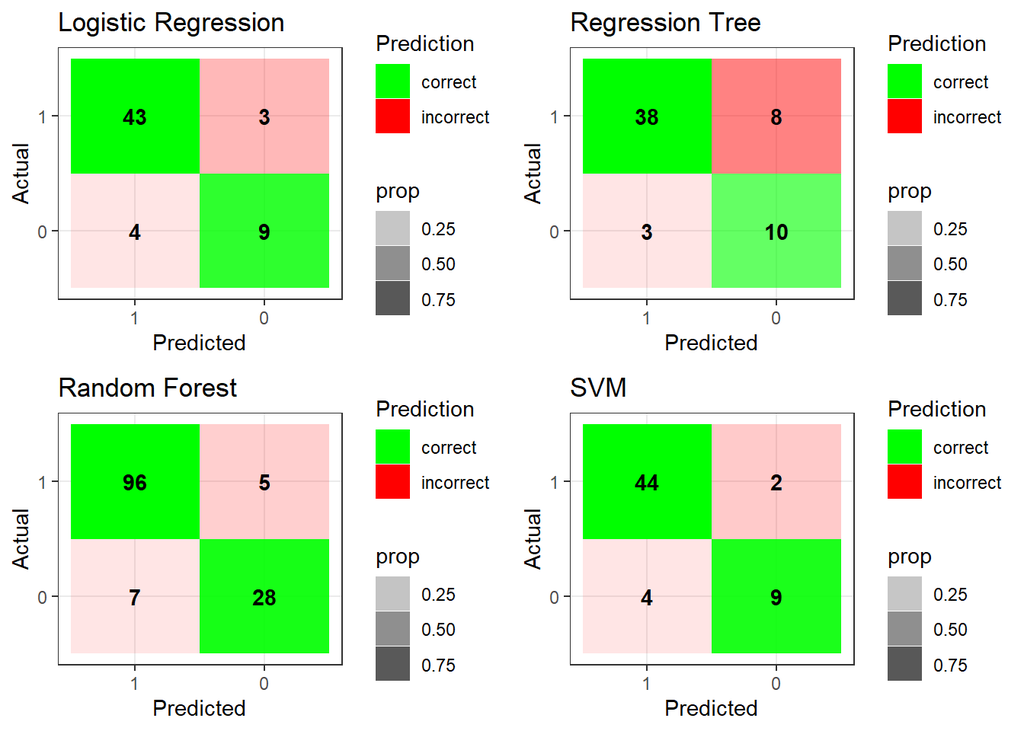

Figure 2: Confusion matrices of the Logistic Regression, Decision Tree, Random Forest, and SVM models.

Green squares are correct predictions and red squares are incorrect.

Table 1: The miss-classification rates of the models.

| Test | Error Rate |
| --- | --- |
| Logistic | 0.119 |
| Regression tree | 0.186 |
| RF Tree | 0.088 |
| SVM | 0.102 |

## Conclusion

Overall, the results of this study suggest that the random forest model is a promising tool for early diagnosis of Parkinson’s disease. Future studies should use larger datasets with a bigger variety of features to confirm the findings of this study and to explore the use of the random forest model for other neurological disorders.

## References

- *[1]*: Zhang, H.-H., Yang, L., Liu, Y., Wang, P., Yin, J., Li, Y., Qiu, M., Zhu, X., & Yan, F. (2016, November 16). Classification of parkinson’s disease utilizing multi-edit nearest-neighbor and ensemble learning algorithms with speech samples. PubMed Central. Retrieved April 30, 2023, from https://www.ncbi.nlm.nih.gov/pmc/articles/PMC5112697/
- *[2]*: ‘Exploiting Nonlinear Recurrence and Fractal Scaling Properties for Voice Disorder Detection’, Little MA, McSharry PE, Roberts SJ, Costello DAE, Moroz IM. BioMedical Engineering OnLine 2007, 6:23 (26 June 2007) https://archive.ics.uci.edu/ml/machine-learning-databases/parkinsons/
- *[3]*: Max A. Little, Patrick E. McSharry, Eric J. Hunter, Lorraine O. Ramig (2008), ‘Suitability of dysphonia measurements for telemonitoring of Parkinson’s disease’, IEEE Transactions on Biomedical Engineering (to appear).
- *[4]*: Little, Max A. (2019). “A Tutorial on Voice Analysis in R”. RPubs. Retrieved from https://rstudio-pubs-static.s3.amazonaws.com/197257_4ecb7314bc1f4619b59ab44a1374ce7f.html
- *[5]*: Wu Y, Chen P, Yao Y, Ye X, Xiao Y, Liao L, Wu M, Chen J. Dysphonic Voice Pattern Analysis of Patients in Parkinson’s Disease Using Minimum Interclass Probability Risk Feature Selection and Bagging Ensemble Learning Methods. Comput Math Methods Med. 2017;2017:4201984. doi: 10.1155/2017/4201984. Epub 2017 May 3. PMID: 28553366; PMCID: PMC5434464.
- *[6]*: Vance, Matt. (2019). “A Tutorial on Voice Analysis in R”. RPubs. Retrieved from https://rpubs.com/VanceMatt/197257

## Appendix

### R Code Used:

```r
#library(tidyverse)
#library(ggplot2)
#library(MASS)
#library(tree)
#library(randomForest)
#library(psych)
#library(caret)
#library(kernlab)
#library(e1071)
#library(reshape2)
#library(kableExtra)
#library(gridExtra)

#parkinsons_data <- read.csv('parkinsons.data')

#set.seed(123)
#################################################### using selected features
#test_Park <- parkinsons_data %>%
#  mutate(parkinson = status)%>%
#  dplyr::select(-c(name,status))

######## find highly correlated features
#cor_matrix2 <-cor(test_Park[,1:22])
#findCorrelation(cor_matrix2, cutoff=0.5)

#Cor mat heat map
#round_cor_mat <- round(cor_matrix2,2)
#melted_corr_mat <- melt(round_cor_mat)

#heat.map <- ggplot(data = melted_corr_mat, aes(x=Var1, y=Var2,fill=value)) +
#  theme(axis.title.y=element_blank(),axis.title.x=element_blank(),
#        axis.text.x = element_text(angle=35, vjust=1, hjust=1)) +
#  scale_fill_gradient2(low = "blue",
#                       mid = "white",
#                       high = "red")+
#  labs(fill="Correlation", title = "Figure 1: Correlation Heat Map")+
#  geom_tile() +
#  geom_text(aes(Var2, Var1, label = value),
#            color = "black", size = 2)

#heat.map

#keep only non-highly correlated features
#MDVP.Fhi.Hz , MDVP.Flo.Hz.,  NHR , RPDE, DFA , spread2, parkinson(status)
#park_subset<-test_Park[,c(2,3,15,17,18,20,23)]

#sub_train <- sample(nrow(park_subset), nrow(park_subset) * 0.7)

#predict_sub_parkinsons.train <- park_subset[sub_train, ]

#predict_sub_parkinsons.test <- park_subset[-sub_train, ]

# glm
#glm.park2 <- glm(parkinson ~ ., family = binomial ,data = predict_sub_parkinsons.train)
#glm.park2

#glm.probs2 <- predict(glm.park2,predict_sub_parkinsons.test, type = 'response' )
#glm.pred2 <- rep(0, nrow(predict_sub_parkinsons.test))
#glm.pred2[glm.probs2 >.5] <- 1

#table(glm.pred2, predict_sub_parkinsons.test$parkinson)
# rate of misclassification

#sub_glm_error_rate<- 1-mean(glm.pred2==predict_sub_parkinsons.test$parkinson)
#paste("The logistic missclasification rate is:", sub_glm_error_rate)

# regression tree

#sub_park_tree <- tree(as.factor(parkinson) ~., data = predict_sub_parkinsons.train)
#plot(sub_park_tree)
#text(sub_park_tree, pretty = 0)

#sub_tree.pred <- predict(sub_park_tree,predict_sub_parkinsons.test, type = 'class')
#table(sub_tree.pred,predict_sub_parkinsons.test$parkinson)
# rate of misclassification
#sub_tree_error_rate<- (1-mean(sub_tree.pred==predict_sub_parkinsons.test$parkinson))
#paste("The regression tree  missclasification rate is:", sub_tree_error_rate)

## RF tree

#sub_rf.parkinsons <- randomForest(as.factor(parkinson) ~ ., data = predict_sub_parkinsons.train, mtry=3, importance=TRUE)
#sub_rf.parkinsons
#varImpPlot(sub_rf.parkinsons)

#paste("The random forest tree  missclasification rate is:", sub_rf.parkinsons$err.rate[500,1])
# paste("The random forest tree  missclasification rate is lower than the logistic model missclasification rate by:", sub_glm_error_rate-(sub_rf.parkinsons$err.rate[500,1]))
# paste("The random forest tree  missclasification rate is lower than the regression tree missclasification rate by:", sub_tree_error_rate-(sub_rf.parkinsons$err.rate[500,1]))


### SVM
#sub_tune.out <- tune(svm, as.factor(parkinson) ~., data=predict_sub_parkinsons.train, kernel ="radial",
#                     ranges =list(cost=c(0.1 ,1 ,10 ,100 ,1000),
#                                  gamma=c(0.5,1,2,3,4) ))
#summary(sub_tune.out)

#svm.parkinsons_sub <- svm(as.factor(parkinson) ~ .,
#                          data = predict_sub_parkinsons.train,
#                          kernel = "radial",
#                          gamma = 0.5,
#                          cost = 100)

#svm.parkinsons.predictions_sub <- predict(svm.parkinsons_sub, predict_sub_parkinsons.test)
#summary(svm.parkinsons.predictions_sub)

#table( svm.parkinsons.predictions_sub,predict_sub_parkinsons.test$parkinson)

#svm_error_rate<- (1-mean(svm.parkinsons.predictions_sub==predict_sub_parkinsons.test$parkinson))
#paste("The svm  missclasification rate is:", svm_error_rate)

# paste("The svm  missclasification rate is lower than the logistic model missclasification rate by:", sub_glm_error_rate-svm_error_rate)
# paste("The svm  missclasification rate is lower than the regression tree missclasification rate by:", sub_tree_error_rate-svm_error_rate)
# paste("The svm  missclasification rate is lower than the random forest tree missclasification rate by:", (sub_rf.parkinsons$err.rate[500,1])-svm_error_rate)

###############error rate table
#model_type <- c('Logistic','Regression tree','RF Tree','SVM')
#error_rate <- c(sub_glm_error_rate,sub_tree_error_rate,sub_rf.parkinsons$err.rate[500,1],svm_error_rate)
#error_table <- data.frame(model_type,error_rate)
#error_table

#error.kable <- kable(error_table, caption = "Table 1: The miss-classification rates of the models.", booktabs = TRUE,
#                     escape = F,
#                     digits = 3,
#                     longtable = T,
#                     col.names = c("Test", "Error Rate")) %>%
#  kable_styling(latex_options = "striped",full_width = FALSE)

############################# confusion matrix visualizations

#SVM    #####
#svm_tab <-data.frame(table(svm.parkinsons.predictions_sub,predict_sub_parkinsons.test$parkinson))

#plotTable <- svm_tab %>%
#  mutate(Prediction = ifelse(svm_tab$Var2 == svm_tab$svm.parkinsons.predictions_sub, "correct", "incorrect")) %>%
#  group_by(svm.parkinsons.predictions_sub) %>%
#  mutate(prop = Freq/sum(Freq))


#plot1 <- ggplot(data = plotTable, mapping = aes(x = svm.parkinsons.predictions_sub, y = Var2, fill = Prediction, alpha = prop)) +
#  geom_tile() +
#  geom_text(aes(label = Freq), vjust = .5, fontface  = "bold", alpha = 1) +
#  scale_fill_manual(values = c(correct = "green", incorrect = "red")) +
#  theme_bw() +
#  xlim(rev(levels(svm_tab$svm.parkinsons.predictions_sub)))+
#  labs(x="Predicted", y='Actual',title = "SVM")

#Log Reg #####
#log_tab <-data.frame(table(glm.pred2, predict_sub_parkinsons.test$parkinson))

#log_plotTable <- log_tab %>%
#  mutate(Prediction = ifelse(log_tab$Var2 == log_tab$glm.pred2, "correct", "incorrect")) %>%
#  group_by(glm.pred2) %>%
#  mutate(prop = Freq/sum(Freq))

#plot2 <- ggplot(data = log_plotTable, mapping = aes(x = glm.pred2, y = Var2, fill = Prediction, alpha = prop)) +
#  geom_tile() +
#  geom_text(aes(label = Freq), vjust = .5, fontface  = "bold", alpha = 1) +
#  scale_fill_manual(values = c(correct = "green", incorrect = "red")) +
#  theme_bw() +
#  xlim(rev(levels(log_tab$glm.pred2)))+
#  labs(x="Predicted", y='Actual',title = 'Logistic Regression')

#Reg Tree

#tree_tab <-data.frame(table(sub_tree.pred, predict_sub_parkinsons.test$parkinson))

#tree_plotTable <- tree_tab %>%
#  mutate(Prediction = ifelse(tree_tab$Var2 == tree_tab$sub_tree.pred, "correct", "incorrect")) %>%
#  group_by(sub_tree.pred) %>%
#  mutate(prop = Freq/sum(Freq))

#plot3 <- ggplot(data = tree_plotTable, mapping = aes(x = sub_tree.pred, y = Var2, fill = Prediction, alpha = prop)) +
#  geom_tile() +
#  geom_text(aes(label = Freq), vjust = .5, fontface  = "bold", alpha = 1) +
#  scale_fill_manual(values = c(correct = "green", incorrect = "red")) +
#  theme_bw() +
#  xlim(rev(levels(tree_tab$sub_tree.pred)))+
#  labs(x="Predicted", y='Actual', title = 'Regression Tree')

# RF
#rf_tab <-data.frame(sub_rf.parkinsons$confusion) %>%
#  dplyr::select(-class.error)%>%
#  mutate(actual= c(0,1))%>%
#  pivot_longer(cols = c('X0','X1'),
#               names_to = 'rf.pred',
#               values_to = 'Freq')%>%
#  mutate(rf.pred= case_when(rf.pred=="X0"~0,rf.pred=="X1"~1))%>%
#  mutate(rf.pred= factor(rf.pred))%>%
#  mutate(actual= factor(actual))

#rf_plotTable <- rf_tab %>%
#  mutate(Prediction = ifelse(rf_tab$actual == rf_tab$rf.pred, "correct", "incorrect")) %>%
#  group_by(rf.pred) %>%
#  mutate(prop = Freq/sum(Freq))

#plot4 <- ggplot(data = rf_plotTable, mapping = aes(x = rf.pred, y = actual, fill = Prediction, alpha = prop)) +
#  geom_tile() +
#  geom_text(aes(label = Freq), vjust = .5, fontface  = "bold", alpha = 1) +
#  scale_fill_manual(values = c(correct = "green", incorrect = "red")) +
#  theme_bw() +
#  labs(x="Predicted", y='Actual', title = "Random Forest")+
#  xlim(rev(levels(rf_tab$rf.pred)))

# Grip Plot
# grid.arrange(plot2,plot3,plot4,plot1)
```